# Chapter 3: Logistic Regression

## Data analysis

### 2. Reading the data and description of the dataset

For this we have to include the library *dplyr* (`library(dplyr)`) which is a common R library used for data wrangling

```r
library(dplyr)
```

```r
alc <- read.csv("./data/alc.csv")
```

To get an overview on the dataset, let’s print out the names of the variables. Description of the data set:

```r
colnames(alc)
```

```
##  [1] "X"          "school"     "sex"        "age"        "address"
##  [6] "famsize"    "Pstatus"    "Medu"       "Fedu"       "Mjob"
## [11] "Fjob"       "reason"     "nursery"    "internet"   "guardian"
## [16] "traveltime" "studytime"  "failures"   "schoolsup"  "famsup"
## [21] "paid"       "activities" "higher"     "romantic"   "famrel"
## [26] "freetime"   "goout"      "Dalc"       "Walc"       "health"
## [31] "absences"   "G1"         "G2"         "G3"         "alc_use"
## [36] "high_use"
```

### 3. Relation of different values to high/low alcohol consumption

Choose 4 interesting variables from the data and formulate hypothesis towards their relationship with alcohol consumption

**Hypothesis 1**: *sex*: There is a statistical difference concerning sex: Males are more likely to have a high alcohol consumption.

**Hypothesis 2** *failure*: Number of past class failures has a relation to alcohol consumption.

**Hypothesis 3** *famrel*: Good family relationships make high alcohol consume less likely.

**Hypothesis 4** *goout*: The frequency of going out with friends will affect the alcohol consumption.

### 4. Numerical and graphical exploration of chosen variables

distributions (cross-tabulations, bar plots, box plots), comment on findings, comparison to hypotheses

```r
#library(tidyr); library(dplyr); library(ggplot2)
# draw a bar plot of each variable
#gather(alc) %>% ggplot(aes(value)) + facet_wrap("key", scales = "free") + geom_bar()
```

```r
alc %>% group_by(sex, high_use) %>% summarise(count=n())
```

```
## # A tibble: 4 x 3
## # Groups:   sex [2]
##   sex   high_use count
##   <chr> <lgl>    <int>
## 1 F     FALSE      156
## 2 F     TRUE        42
## 3 M     FALSE      112
## 4 M     TRUE        72
```

This is supporting **Hypothesis 1**. Whereas 21.2121212% of the female students mention a high alcohol consumption, 39.1304348% of the male students have a high use, which is almost the double value. To look at this graphically, let’s look at a bar plot.

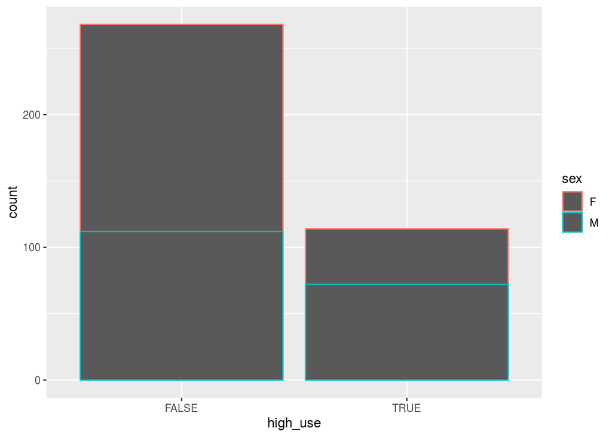

```r
library(ggplot2)
g2 <- ggplot(alc, aes(x = high_use, col=sex))
g2 + geom_bar()
```

The bar plot shows quite clearly, that the difference between high-use and no high-use are quite different for male and female students.

**Hypothesis 2**: Let’s now investigate if one can see a clear relation between the failures and the alcohol consumption.

```r
alc %>% group_by(high_use) %>% summarise(count=n())
```

```
## # A tibble: 2 x 2
##   high_use count
##   <lgl>    <int>
## 1 FALSE      268
## 2 TRUE       114
```

```r
alc %>% group_by(failures) %>% summarise(count=n())
```

```
## # A tibble: 4 x 2
##   failures count
##      <int> <int>
## 1        0   334
## 2        1    24
## 3        2    19
## 4        3     5
```

```r
alc %>% group_by(high_use, failures) %>% summarise(count=n())
```

```
## # A tibble: 8 x 3
## # Groups:   high_use [2]
##   high_use failures count
##   <lgl>       <int> <int>
## 1 FALSE           0   244
## 2 FALSE           1    12
## 3 FALSE           2    10
## 4 FALSE           3     2
## 5 TRUE            0    90
## 6 TRUE            1    12
## 7 TRUE            2     9
## 8 TRUE            3     3
```

```r
alc %>% group_by(high_use, failures>0) %>% summarise(count=n())
```

```
## # A tibble: 4 x 3
## # Groups:   high_use [2]
##   high_use `failures > 0` count
##   <lgl>    <lgl>          <int>
## 1 FALSE    FALSE            244
## 2 FALSE    TRUE              24
## 3 TRUE     FALSE             90
## 4 TRUE     TRUE              24
```

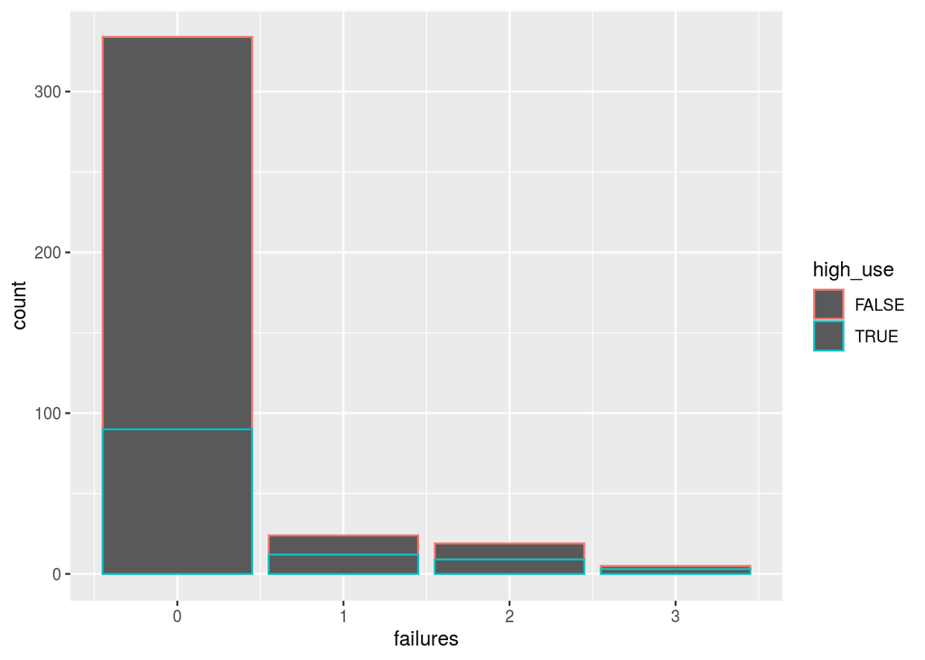

```r
g3 <- ggplot(alc, aes(x=failures, col=high_use))
g3 + geom_bar()
```

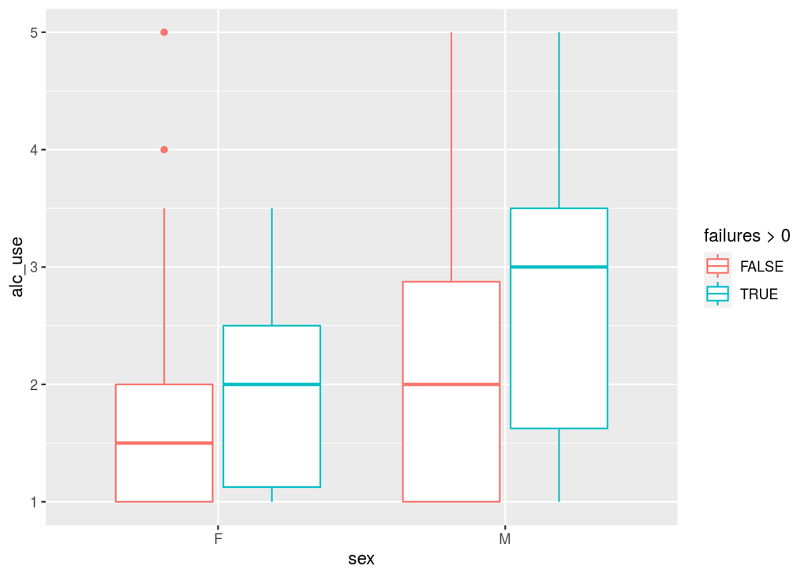

```r
g4 <- ggplot(alc, aes(x = sex, y = alc_use, col=failures>0))
g4 + geom_boxplot()
```

Looking at the bar plot, one might at least come to the conclusion, that having experienced no failure makes it less likely to become addicted to high alcoholic consumption. However, the sample for having a failure is much less than for having none. It might make more sense to combine the numbers for failures > 1 together. Now, a box plot gives a nice visualisation of how having experienced at least 1 failure can impact the alcoholic consumption. Again, the impact seems to be much higher for the mail students.

### 5. Logistic regression

### 6. Predictive power of Model

### 7. Bonus: 10-fold cross-validation

### 8. Super-Bonus